# Trading Statistics

Author

Ingo Miller

Published

05/03/2024

# 1 Summary

**Invested Capital:**  
- Options: **$9,785**  
- Swing Trades: **$237.46**

**Current Exchange Rates:**  
- **EUR:USD:** *1.086*  
- **EUR:USD:** *0.921*

# 2 Option Trading

## 2.1 Performance

Active Option Trades: 7  
Capital Committed: **$12,200**

**Table** 1: Active Options

| Symbol | End | Strike | P/C | GTC |
| --- | --- | --- | --- | --- |
| HUT | Mar 08 '24 | 7.0 | PUT | NA |
| JD | Mar 08 '24 | 29.5 | CALL | NA |
| MARA | Mar 08 '24 | 18.0 | PUT | 0.01 |
| NEM | Mar 08 '24 | 30.5 | PUT | 0.01 |
| SEDG | Mar 08 '24 | 59.0 | PUT | 0.02 |
| CGC | Mar 15 '24 | 3.5 | PUT | NA |
| NIO | Mar 08 '24 | 4.0 | PUT | NA |

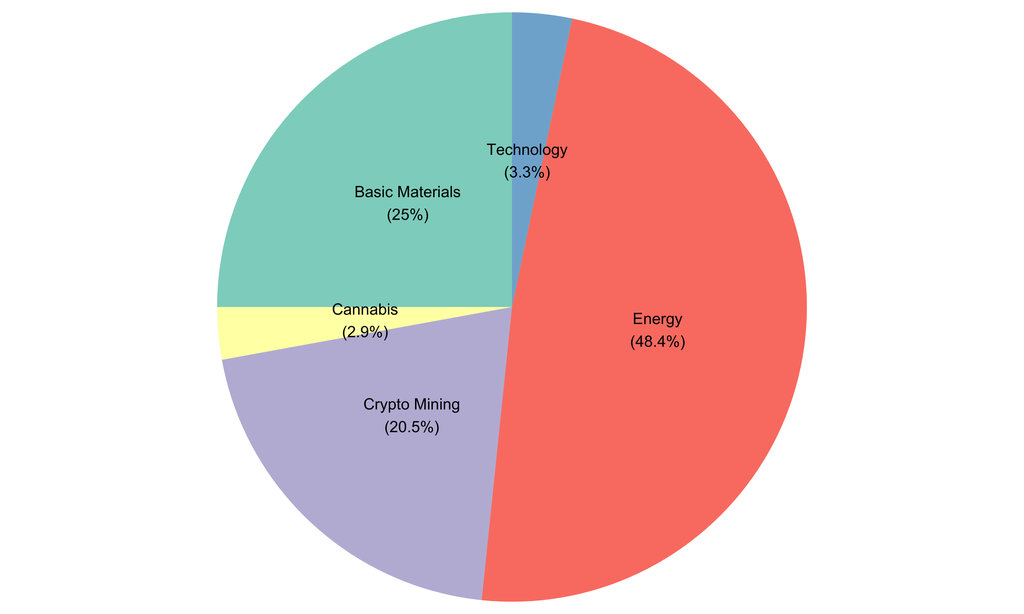

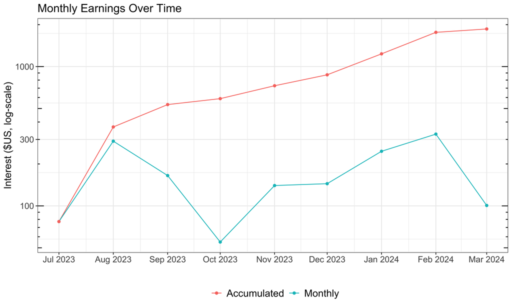

**Figure** 1: Net interest earned through options trading over time, summarised by month

**Weekly Summary**

Weekly performance is summarised in Table 2. Gross interest refers to interest in USD excluding broker fees, while Net Interest shows USD earned with broker fees accounted for. Mean interest per trade shows the average interest earned per trade in percent, while Interest earned refers to the total interest earned in percent for the given timer period. The sum of capital committed shows how much money was committed for option trade in the given time period, and the last column shows the mean capital committed per trade.

**Table** 2: Weekly performance of option trades since trading commenced

| Year | Week | Available_$ | Trades | Gross_Interest_$ | Net_Interest_$ | Mean_Interest/Trade_% | Interest_earned_% | Sum_Committed_$ | Mean_Committed_$ |
| --- | --- | --- | --- | --- | --- | --- | --- | --- | --- |
| 2023 | 30 | 14394 | 4 | 63 | 56.9 | 0.3 | 0.4 | 19200 | 4800.0 |
| 2023 | 31 | 19696 | 7 | 85 | 72.1 | 0.3 | 0.4 | 25800 | 3685.7 |
| 2023 | 32 | 19877 | 6 | 109 | 99.1 | 0.4 | 0.5 | 14850 | 2475.0 |
| 2023 | 33 | 19642 | 2 | 43 | 40.3 | 0.4 | 0.2 | 4300 | 2150.0 |
| 2023 | 34 | 19642 | 5 | 70 | 62.5 | 0.3 | 0.3 | 13600 | 2720.0 |
| 2023 | 35 | 19516 | 5 | 46 | 37.7 | 0.2 | 0.2 | 15650 | 3130.0 |
| 2023 | 36 | 19516 | 3 | 53 | 48.9 | 0.4 | 0.3 | 3250 | 1083.3 |
| 2023 | 37 | 19335 | 1 | 10 | 9.4 | 0.4 | 0.0 | 2200 | 2200.0 |
| 2023 | 38 | 19154 | 4 | 86 | 82.2 | 0.5 | 0.4 | 1900 | 475.0 |
| 2023 | 39 | 19154 | 2 | 26 | 24.6 | 0.3 | 0.1 | 0 | 0.0 |
| 2023 | 43 | 18974 | 1 | 28 | 26.5 | 0.4 | 0.1 | 0 | 0.0 |
| 2023 | 44 | 19154 | 3 | 69 | 64.6 | 0.7 | 0.3 | 8950 | 2983.3 |
| 2023 | 45 | 19154 | 1 | 10 | 8.1 | 0.2 | 0.0 | 3550 | 3550.0 |
| 2023 | 46 | 19154 | 4 | 78 | 70.4 | 2.4 | 0.4 | 6350 | 1587.5 |
| 2023 | 47 | 19696 | 1 | 12 | 10.3 | 0.2 | 0.1 | 5500 | 5500.0 |
| 2023 | 48 | 19696 | 1 | 16 | 15.0 | 0.3 | 0.1 | 4850 | 4850.0 |
| 2023 | 49 | 19393 | 1 | 11 | 10.0 | 0.3 | 0.1 | 3400 | 3400.0 |
| 2023 | 50 | 19393 | 2 | 25 | 21.7 | 0.2 | 0.1 | 9350 | 4675.0 |
| 2023 | 51 | 19393 | 4 | 54 | 48.9 | 0.3 | 0.3 | 11600 | 2900.0 |
| 2023 | 52 | 11622 | 4 | 68 | 63.8 | 0.9 | 0.5 | 9250 | 2312.5 |
| 2024 | 1 | 11570 | 4 | 50 | 45.0 | 0.3 | 0.4 | 10700 | 2675.0 |
| 2024 | 2 | 11539 | 5 | 59 | 53.6 | 0.7 | 0.5 | 10750 | 2150.0 |
| 2024 | 3 | 6879 | 5 | 66 | 60.1 | 0.7 | 0.9 | 7550 | 1510.0 |
| 2024 | 4 | 12100 | 1 | 5 | 3.5 | 0.3 | 0.0 | 1300 | 1300.0 |
| 2024 | 5 | 13949 | 6 | 94 | 84.4 | 0.9 | 0.6 | 14250 | 2375.0 |
| 2024 | 6 | 13974 | 8 | 71 | 58.5 | 1.0 | 0.4 | 18750 | 2343.8 |
| 2024 | 7 | 14007 | 11 | 157 | 142.5 | 1.1 | 1.0 | 22850 | 2077.3 |
| 2024 | 8 | 11819 | 6 | 25 | 15.8 | 0.1 | 0.1 | 7550 | 1258.3 |
| 2024 | 9 | 11915 | 9 | 123 | 110.8 | 0.8 | 0.9 | 15850 | 1761.1 |
| 2024 | 10 | 12008 | 4 | 104 | 100.6 | 4.6 | 0.8 | 9700 | 2425.0 |

Table 3 shows the success rate in percent for the given time period for closed positions only. Active options are excluded from this overview as the outcome is still open.

**Table** 3: Weekly success rates of options excluding repair strategy

| Year | month | Week | SuccessRate_% | Trades |
| --- | --- | --- | --- | --- |
| 2023 | 07 | 30 | 100.0 | 4 |
| 2023 | 07 | 31 | 100.0 | 3 |
| 2023 | 08 | 31 | 75.0 | 4 |
| 2023 | 08 | 32 | 100.0 | 5 |
| 2023 | 08 | 33 | 0.0 | 1 |
| 2023 | 08 | 34 | 100.0 | 4 |
| 2023 | 08 | 35 | 100.0 | 5 |
| 2023 | 09 | 36 | 0.0 | 1 |
| 2023 | 09 | 37 | 0.0 | 1 |
| 2023 | 09 | 38 | 0.0 | 1 |
| 2023 | 11 | 44 | 100.0 | 2 |
| 2023 | 11 | 45 | 100.0 | 1 |
| 2023 | 11 | 46 | 100.0 | 3 |
| 2023 | 11 | 47 | 100.0 | 1 |
| 2023 | 11 | 48 | 100.0 | 1 |
| 2023 | 12 | 49 | 100.0 | 1 |
| 2023 | 12 | 50 | 100.0 | 2 |
| 2023 | 12 | 51 | 100.0 | 3 |
| 2023 | 12 | 52 | 100.0 | 3 |
| 2024 | 01 | 1 | 100.0 | 3 |
| 2024 | 01 | 2 | 60.0 | 5 |
| 2024 | 01 | 3 | 33.3 | 3 |
| 2024 | 01 | 4 | 100.0 | 3 |
| 2024 | 01 | 5 | 100.0 | 5 |
| 2024 | 02 | 6 | 87.5 | 8 |
| 2024 | 02 | 7 | 88.9 | 9 |
| 2024 | 02 | 8 | 100.0 | 5 |
| 2024 | 02 | 9 | 100.0 | 6 |

**Monthly Summary**

Monthly performance is summarised in Table 4. Gross interest refers to interest in USD excluding broker fees, while Net Interest shows USD earned with broker fees accounted for. Mean interest per trade shows the average interest earned per trade in percent, while Interest earned refers to the total interest earned in percent for the given timer period. The sum of capital committed shows how much money was committed for option trade in the given time period, and the last column shows the mean capital committed per trade.

**Table** 4: Monthly performance of option trades since trading commenced

| Year | Month | Available_$ | Trades | Gross_Interest_$ | Net_Interest_$ | Mean_Interest/Trade_% | Interest_earned_% | Sum_Committed_$ | Mean_Committed_$ |
| --- | --- | --- | --- | --- | --- | --- | --- | --- | --- |
| 2023 | 7 | 16666 | 7 | 88 | 77.2 | 0.3 | 0.5 | 25050 | 3578.6 |
| 2023 | 8 | 19687 | 22 | 328 | 291.5 | 0.3 | 1.5 | 68350 | 3106.8 |
| 2023 | 9 | 19281 | 10 | 175 | 165.1 | 0.4 | 0.9 | 7350 | 735.0 |
| 2023 | 10 | 19064 | 2 | 58 | 55.0 | 0.9 | 0.3 | 0 | 0.0 |
| 2023 | 11 | 19275 | 9 | 155 | 140.0 | 1.2 | 0.7 | 29200 | 3244.4 |
| 2023 | 12 | 16567 | 11 | 158 | 144.3 | 0.5 | 0.9 | 33600 | 3054.5 |
| 2024 | 1 | 11276 | 23 | 274 | 246.6 | 0.6 | 2.2 | 44550 | 2121.4 |
| 2024 | 2 | 13059 | 34 | 376 | 327.5 | 0.8 | 2.5 | 65000 | 1911.8 |
| 2024 | 3 | 12008 | 4 | 104 | 100.6 | 4.6 | 0.8 | 9700 | 2425.0 |

Table 5 shows the success rate in percent for the given time period for closed positions only. Active options are excluded from this overview as the outcome is still open.

**Table** 5: Monthly success rates of options excluding repair strategy

| Year | month | SuccessRate_% | Trades |
| --- | --- | --- | --- |
| 2023 | 07 | 100.0 | 7 |
| 2023 | 08 | 89.5 | 19 |
| 2023 | 09 | 0.0 | 3 |
| 2023 | 11 | 100.0 | 8 |
| 2023 | 12 | 100.0 | 9 |
| 2024 | 01 | 78.9 | 19 |
| 2024 | 02 | 92.9 | 28 |

**Yearly Summary**

Yearly performance is summarised in Table 6. Gross interest refers to interest in USD excluding broker fees, while Net Interest shows USD earned with broker fees accounted for. Mean interest per trade shows the average interest earned per trade in percent, while Interest earned refers to the total interest earned in percent for the given timer period. The sum of capital committed shows how much money was committed for option trade in the given time period, and the last column shows the mean capital committed per trade.

**Table** 6: Yearly performance of option trades since trading commenced

| Year | Available_$ | Trades | Gross_Interest_$ | Net_Interest_$ | Mean_Interest/Trade_% | Interest_earned_% | Sum_Committed_$ | Mean_Committed_$ |
| --- | --- | --- | --- | --- | --- | --- | --- | --- |
| 2023 | 18630 | 61 | 962 | 873.0 | 0.5 | 4.7 | 163550 | 2681.1 |
| 2024 | 12318 | 61 | 754 | 674.8 | 1.0 | 5.5 | 119250 | 2021.2 |

Table 7 shows the success rate in percent for the given time period for closed positions only. Active options are excluded from this overview as the outcome is still open.

**Table** 7: Yearly success rates of options excluding repair strategy

| Year | SuccessRate_% | Trades |
| --- | --- | --- |
| 2023 | 89.1 | 46 |
| 2024 | 87.2 | 47 |

## 2.2 Investment Performance

**Table** 8: Investment performance of bought stocks through options

| Symbol | Date_Invested | Date_Closed | Days_Invested | Invested_Capital | Mean_Strike | Contracts | Trades | Sell_Price | Sell_Profit | Earnings | Earnings_% | Return_$ | Return_% |
| --- | --- | --- | --- | --- | --- | --- | --- | --- | --- | --- | --- | --- | --- |
| PYPL | 2023-08-02 | 2024-01-19 | 170 | 6400 | 64.0 | 1 | 15 | 6400 | 0 | 331.7 | 5.2 | 331.7 | 5.2 |
| SE | 2023-08-15 | 2023-10-13 | 59 | 4300 | 43.0 | 1 | 4 | 4300 | 0 | 76.5 | 1.8 | 76.5 | 1.8 |
| JD | 2023-09-01 | ACTIVE | 186 | 5800 | 29.0 | 2 | 10 | Inf | Inf | 126.9 | 2.2 | Inf | Inf |
| CHWY | 2023-09-08 | 2023-11-17 | 70 | 4100 | 20.5 | 2 | 5 | 4100 | 0 | 86.6 | 2.1 | 86.6 | 2.1 |
| PARA | 2024-01-05 | 2024-01-25 | 20 | 1350 | 13.5 | 1 | 2 | 1445 | 95 | 4.8 | 0.4 | 99.8 | 7.4 |
| HUT | 2024-01-12 | 2024-02-16 | 35 | 800 | 8.0 | 1 | 6 | 1000 | 200 | 67.5 | 8.4 | 267.5 | 33.4 |
| BILI | 2024-01-16 | 2024-01-25 | 9 | 950 | 9.5 | 1 | 2 | 970 | 20 | 5.5 | 0.6 | 25.5 | 2.7 |
| CGC | 2024-02-08 | ACTIVE | 26 | 400 | 4.0 | 1 | 7 | Inf | Inf | 104.7 | 26.2 | Inf | Inf |
| DBX | 2024-02-15 |  | NA | 2900 | 29.0 | 1 | 1 | Inf | Inf | 19.0 | 0.7 | Inf | Inf |

**Weekly**

**Table** 9: Weekly profits from closed options that were assigned

| Year | Month | Week | Profit |
| --- | --- | --- | --- |
| 2023 | 10 | 41 | 0 |
| 2023 | 11 | 46 | 0 |
| 2024 | 1 | 3 | 0 |
| 2024 | 1 | 4 | 115 |
| 2024 | 2 | 7 | 200 |
| NA | NA | NA | Inf |

**Monthly**

**Table** 10: Monthly profits from closed options that were assigned

| Year | Month | Profit |
| --- | --- | --- |
| 2023 | 10 | 0 |
| 2023 | 11 | 0 |
| 2024 | 1 | 115 |
| 2024 | 2 | 200 |
| NA | NA | Inf |

**Yearly**

**Table** 11: Yearly profits from closed options that were assigned

| Year | Profit |
| --- | --- |
| 2023 | 0 |
| 2024 | 315 |
| NA | Inf |

# 3 Swing Trades

**Active Swings**

**Table** 12: Currently active swing trades

| Symbol | Date_Invested | Strategy | Mean_Strike | Target | Trades | Shares | Invested_$ | Portfolio_% |
| --- | --- | --- | --- | --- | --- | --- | --- | --- |
| BABA | 2023-11-29 | long | $74.955 | $79.9 | 1 | 2 | 149.9 | 1 |
| CRM | 2023-12-22 | short | $266.4 | $216 | 1 | -1 | -266.4 | 1 |
| HUT | 2024-01-10 | long | $12 | $20 | 1 | 15 | 180.0 | 1 |
| NEM | 2024-01-17 | long | $34.79 | $39 | 1 | 5 | 173.9 | 1 |

**Closed Swings**

**Summary by Position**

**Table** 13: Closed swing trades and performance

| Symbol | Campaign | Date_Invested | Strategy | Mean_Strike | Trades | Shares | Invested_$ | Portfolio_% | Date_Closed | Days | Closing_$ | Dividents_$ | Commissions_$ | Profit |
| --- | --- | --- | --- | --- | --- | --- | --- | --- | --- | --- | --- | --- | --- | --- |
| AG | 1 | 2023-11-02 | long | $4.43 | 1 | 40 | 177.2 | 1 | 2023-11-07 | 5 | 192.0 | 0.0 | 2 | $12.8 |
| ARFM | 1 | 2023-12-08 | short | $44.99 | 3 | -12 | -539.9 | 6 | 2024-01-17 | 40 | 480.0 | 0.0 | 4 | $63.88 |
| DISH | 1 | 2023-11-21 | long | $3.625 | 1 | 50 | 181.2 | 1 | 2023-12-07 | 16 | 215.2 | 0.0 | 2 | $32 |
| GIS | 1 | 2023-07-17 | long | $75.1 | 1 | 2 | 150.2 | 1 | 2023-07-20 | 3 | 152.6 | 0.0 | 2 | $0.370000000000005 |
| LUV | 1 | 2023-08-25 | long | $26.08 | 3 | 15 | 391.2 | 6 | 2023-12-07 | 104 | 437.2 | 0.9 | 4 | $42.95 |
| NEM | 1 | 2023-08-04 | long | $37.6575 | 4 | 18 | 674.1 | 10 | 2023-12-01 | 119 | 740.2 | 10.4 | 5 | $71.52 |
| PFE | 1 | 2023-11-13 | long | $29 | 1 | 6 | 174.0 | 1 | 2023-11-21 | 8 | 181.1 | 0.0 | 2 | $5.14000000000001 |
| ROKU | 1 | 2023-11-20 | short | $101.35 | 2 | -4 | -405.4 | 3 | 2023-12-15 | 25 | 396.5 | 0.0 | 3 | $11.88 |

**Weekly**

**Table** 14: Weekly Swing trade profits

| Year | Month | Week | Weekly_Profit |
| --- | --- | --- | --- |
| 2023 | 7 | 29 | 0.4 |
| 2023 | 11 | 45 | 12.8 |
| 2023 | 11 | 47 | 5.1 |
| 2023 | 12 | 48 | 71.5 |
| 2023 | 12 | 49 | 75.0 |
| 2023 | 12 | 50 | 11.9 |
| 2024 | 1 | 3 | 63.9 |

**Monthly**

**Table** 15: Monthly Swing trade profits

| Year | Month | Monthly_Profit |
| --- | --- | --- |
| 2023 | 7 | 0.4 |
| 2023 | 11 | 17.9 |
| 2023 | 12 | 158.3 |
| 2024 | 1 | 63.9 |

**Yearly**

**Table** 16: Yearly Swing trade profits

| Year | Yearly_Profit |
| --- | --- |
| 2023 | 176.7 |
| 2024 | 63.9 |

# 4 Combined Performance from Options, Stocks, and Swing trades

**Last Weeks Performance Summary:**

| Year | Week | Options_$ | Swings_$ | Stocks_$ | Sum_Profit_$ | Interest_Options_% | Interest_Total_% |
| --- | --- | --- | --- | --- | --- | --- | --- |
| 2024 | 9 | 110.8 | 0 | 0 | 110.8 | 0.9 | 0.9 |

**Last Months Performance Summary:**

| Year | Month | Options_$ | Swings_$ | Stocks_$ | Sum_Profit_$ | Interest_Options_% | Interest_Total_% |
| --- | --- | --- | --- | --- | --- | --- | --- |
| 2024 | 2 | 327.5 | 0 | 200 | 527.5 | 2.5 | 4 |

**Last Years Performance Summary:**

| Year | Options_$ | Swings_$ | Stocks_$ | Sum_Profit_$ | Interest_Options_% | Interest_Total_% |
| --- | --- | --- | --- | --- | --- | --- |
| 2023 | 873 | 176.7 | 0 | 1049.6 | 4.7 | 5.6 |

**Weekly**

**Table** 17: Weekly Profits combined

| Year | Week | Options_$ | Swings_$ | Stocks_$ | Sum_Profit_$ | Interest_Options_% | Interest_Total_% |
| --- | --- | --- | --- | --- | --- | --- | --- |
| 2023 | 30 | 56.9 | 0.0 | 0 | 56.9 | 0.4 | 0.4 |
| 2023 | 31 | 72.1 | 0.0 | 0 | 72.1 | 0.4 | 0.4 |
| 2023 | 32 | 99.1 | 0.0 | 0 | 99.1 | 0.5 | 0.5 |
| 2023 | 33 | 40.3 | 0.0 | 0 | 40.3 | 0.2 | 0.2 |
| 2023 | 34 | 62.5 | 0.0 | 0 | 62.5 | 0.3 | 0.3 |
| 2023 | 35 | 37.7 | 0.0 | 0 | 37.7 | 0.2 | 0.2 |
| 2023 | 36 | 48.9 | 0.0 | 0 | 48.9 | 0.3 | 0.3 |
| 2023 | 37 | 9.4 | 0.0 | 0 | 9.4 | 0.0 | 0.0 |
| 2023 | 38 | 82.2 | 0.0 | 0 | 82.2 | 0.4 | 0.4 |
| 2023 | 39 | 24.6 | 0.0 | 0 | 24.6 | 0.1 | 0.1 |
| 2023 | 43 | 26.5 | 0.0 | 0 | 26.5 | 0.1 | 0.1 |
| 2023 | 44 | 64.6 | 0.0 | 0 | 64.6 | 0.3 | 0.3 |
| 2023 | 45 | 8.1 | 12.8 | 0 | 20.9 | 0.0 | 0.1 |
| 2023 | 46 | 70.4 | 0.0 | 0 | 70.4 | 0.4 | 0.4 |
| 2023 | 47 | 10.3 | 5.1 | 0 | 15.5 | 0.1 | 0.1 |
| 2023 | 48 | 15.0 | 71.5 | 0 | 86.5 | 0.1 | 0.4 |
| 2023 | 49 | 10.0 | 75.0 | 0 | 84.9 | 0.1 | 0.4 |
| 2023 | 50 | 21.7 | 11.9 | 0 | 33.6 | 0.1 | 0.2 |
| 2023 | 51 | 48.9 | 0.0 | 0 | 48.9 | 0.3 | 0.3 |
| 2023 | 52 | 63.8 | 0.0 | 0 | 63.8 | 0.5 | 0.5 |
| 2024 | 1 | 45.0 | 0.0 | 0 | 45.0 | 0.4 | 0.4 |
| 2024 | 2 | 53.6 | 0.0 | 0 | 53.6 | 0.5 | 0.5 |
| 2024 | 3 | 60.1 | 63.9 | 0 | 123.9 | 0.9 | 1.8 |
| 2024 | 4 | 3.5 | 0.0 | 115 | 118.6 | 0.0 | 1.0 |
| 2024 | 5 | 84.4 | 0.0 | 0 | 84.4 | 0.6 | 0.6 |
| 2024 | 6 | 58.5 | 0.0 | 0 | 58.5 | 0.4 | 0.4 |
| 2024 | 7 | 142.5 | 0.0 | 200 | 342.5 | 1.0 | 2.4 |
| 2024 | 8 | 15.8 | 0.0 | 0 | 15.8 | 0.1 | 0.1 |
| 2024 | 9 | 110.8 | 0.0 | 0 | 110.8 | 0.9 | 0.9 |
| 2024 | 10 | 100.6 | 0.0 | 0 | 100.6 | 0.8 | 0.8 |

**Monthly**

**Table** 18: Monthly Profits combined

| Year | Month | Options_$ | Swings_$ | Stocks_$ | Sum_Profit_$ | Interest_Options_% | Interest_Total_% |
| --- | --- | --- | --- | --- | --- | --- | --- |
| 2023 | 7 | 77.2 | 0.4 | 0 | 77.5 | 0.5 | 0.5 |
| 2023 | 8 | 291.5 | 0.0 | 0 | 291.5 | 1.5 | 1.5 |
| 2023 | 9 | 165.1 | 0.0 | 0 | 165.1 | 0.9 | 0.9 |
| 2023 | 10 | 55.0 | 0.0 | 0 | 55.0 | 0.3 | 0.3 |
| 2023 | 11 | 140.0 | 17.9 | 0 | 157.9 | 0.7 | 0.8 |
| 2023 | 12 | 144.3 | 158.3 | 0 | 302.7 | 0.9 | 1.8 |
| 2024 | 1 | 246.6 | 63.9 | 115 | 425.5 | 2.2 | 3.8 |
| 2024 | 2 | 327.5 | 0.0 | 200 | 527.5 | 2.5 | 4.0 |
| 2024 | 3 | 100.6 | 0.0 | 0 | 100.6 | 0.8 | 0.8 |

**Yearly**

**Table** 19: Yearly Profits combined

| Year | Options_$ | Swings_$ | Stocks_$ | Sum_Profit_$ | Interest_Options_% | Interest_Total_% |
| --- | --- | --- | --- | --- | --- | --- |
| 2023 | 873.0 | 176.7 | 0 | 1049.6 | 4.7 | 5.6 |
| 2024 | 674.8 | 63.9 | 315 | 1053.7 | 5.5 | 8.6 |